# chapter4.Rmd

### 1. Statistical summaries of the variables in the `Boston` dataset.

- **`crim` (Crime Rate):** Indicats a right-skewed distribution.The majority of towns have lower crime rates, with 25% having a rate below 0.08205, but a few towns have high crime rate.
- **`zn` (Proportion of Residential Land):** Shows a right-skewed distribution with many towns having little residential land.
- **`indus` (Proportion of Non-Retail Business Acres):** Display a mix of industrial and residential areas.
- **`chas` (Charles River Dummy Variable):** Most suburbs don’t border the Charles river, only 6.92% of towns border the river.
- **`nox` (Nitrogen Oxides Concentration):** Concentration ranges from 0.385 to 0.871. Mean of 0.5547 suggests a moderate level of nitrogen oxides in most zones, but some zones hace high level of nitrogen oxides.
- **`rm` (Average Number of Rooms):** Display a normal distribution, shoing the most have median number of 6.208 rooms.
- **`age` (Proportion of Older Units):** Mean of 68.57 suggests a mix of older and newer units. The distribution is left-skewed indicating many houses are older.
- **`dis` (Weighted Mean of Distances to Employment Centers):** The right-skewed distribution of the `dis` variable suggests that most suburbs have a relatively short distance to employment centers, as indicated by lower values.
- **`rad` (Index of Accessibility to Radial Highways):** `rad` variable appears bimodal, suggesting that suburbs tend to fall into two categories: those that are very close to highways and those that are very far
- **`tax` (Property Tax Rate):** Shows bimodal, ranges from 187 to 711.
- **`ptratio` (Pupil-Teacher Ratio):** Mean of 18.46 indicates a moderate pupil-teacher ratio.
- **`black` (Proportion of Blacks):** Mean of 356.67 suggests a mix of racial proportions.
- **`lstat` (Lower Status of the Population):** Mean of 12.65 indicates a mix of lower and higher-status populations.
- **`medv` (Median Value of Homes):** Mean of 22.53 indicates a moderate median home value.

### 2. Relationships between the variables

**Positive correlation:** - `rm` and `medv`: as more rooms may be associated with higher home values. - `idus` and `nox`: areas with more industrial land use might have higher concentrations of nitrogen oxides. - `age` and `nox`: Older buildings might be associated with higher concentrations of nitrogen oxides. - `rad` and `tax`: There could be a positive correlation between the accessibility to highways and the property tax rate.

**Negtive correlation** - `dis` and `nox`: as areas closer to employment centers might have lower concentrations of nitric oxides. - `rm` and `lstat`: higher-status neighborhoods might have more rooms on average. - `lstat` and `medv`: areas with a lower socioeconomic status might have lower home values.

### 3. Overall Observations:

- The dataset captures a diverse range of features related to housing in Boston suburbs.
- Many variables exhibit right-skewed distributions, suggesting that the majority of towns have lower values.

## Standardize the dataset and print out summaries of the scaled data

```r
# center and standardize variables
boston_scaled <- as.data.frame(scale(Boston))

# summaries of the scaled variables
summary(boston_scaled)
```

```
##       crim                 zn               indus              chas
##  Min.   :-0.419367   Min.   :-0.48724   Min.   :-1.5563   Min.   :-0.2723
##  1st Qu.:-0.410563   1st Qu.:-0.48724   1st Qu.:-0.8668   1st Qu.:-0.2723
##  Median :-0.390280   Median :-0.48724   Median :-0.2109   Median :-0.2723
##  Mean   : 0.000000   Mean   : 0.00000   Mean   : 0.0000   Mean   : 0.0000
##  3rd Qu.: 0.007389   3rd Qu.: 0.04872   3rd Qu.: 1.0150   3rd Qu.:-0.2723
##  Max.   : 9.924110   Max.   : 3.80047   Max.   : 2.4202   Max.   : 3.6648
##       nox                rm               age               dis
##  Min.   :-1.4644   Min.   :-3.8764   Min.   :-2.3331   Min.   :-1.2658
##  1st Qu.:-0.9121   1st Qu.:-0.5681   1st Qu.:-0.8366   1st Qu.:-0.8049
##  Median :-0.1441   Median :-0.1084   Median : 0.3171   Median :-0.2790
##  Mean   : 0.0000   Mean   : 0.0000   Mean   : 0.0000   Mean   : 0.0000
##  3rd Qu.: 0.5981   3rd Qu.: 0.4823   3rd Qu.: 0.9059   3rd Qu.: 0.6617
##  Max.   : 2.7296   Max.   : 3.5515   Max.   : 1.1164   Max.   : 3.9566
##       rad               tax             ptratio            black
##  Min.   :-0.9819   Min.   :-1.3127   Min.   :-2.7047   Min.   :-3.9033
##  1st Qu.:-0.6373   1st Qu.:-0.7668   1st Qu.:-0.4876   1st Qu.: 0.2049
##  Median :-0.5225   Median :-0.4642   Median : 0.2746   Median : 0.3808
##  Mean   : 0.0000   Mean   : 0.0000   Mean   : 0.0000   Mean   : 0.0000
##  3rd Qu.: 1.6596   3rd Qu.: 1.5294   3rd Qu.: 0.8058   3rd Qu.: 0.4332
##  Max.   : 1.6596   Max.   : 1.7964   Max.   : 1.6372   Max.   : 0.4406
##      lstat              medv
##  Min.   :-1.5296   Min.   :-1.9063
##  1st Qu.:-0.7986   1st Qu.:-0.5989
##  Median :-0.1811   Median :-0.1449
##  Mean   : 0.0000   Mean   : 0.0000
##  3rd Qu.: 0.6024   3rd Qu.: 0.2683
##  Max.   : 3.5453   Max.   : 2.9865
```

```r
# create a quantile vector of crim
boston_scaled$crim <- as.numeric(boston_scaled$crim)
bins <- quantile(boston_scaled$crim)
print(bins)
```

```
##           0%          25%          50%          75%         100%
## -0.419366929 -0.410563278 -0.390280295  0.007389247  9.924109610
```

```r
# creat a categorical variable 'crime' based on quantiles
crime <- cut(boston_scaled$crim, breaks = bins, include.lowest = TRUE)
summary(crime)
```

```
## [-0.419,-0.411]  (-0.411,-0.39] (-0.39,0.00739]  (0.00739,9.92]
##             127             126             126             127
```

```r
# create a string vector for labels
labels <- c("low", "med_low", "med_high", "high")

# adjust the cut function by adding the label argument
crime <- cut(boston_scaled$crim, breaks = bins, labels = labels, include.lowest = TRUE)

# look at the table of the new factor crime
table(crime)
```

```
## crime
##      low  med_low med_high     high
##      127      126      126      127
```

```r
# add the new categorical value in the original Boston dataset
Boston$crime <- crime
Boston$crime <- as.factor(Boston$crime)

# remove original crim from the dataset
Boston <- dplyr::select(Boston, -crim)

# divide the dataset into train and test sets (80% train, 20% test)
ind <- sample(nrow(Boston),  size = nrow(Boston) * 0.8)
train <- Boston[ind,]
test <- Boston[-ind,]
```

## Linear Discriminant Analysis

```r
# Fit the linear discriminant analysis on the train set
lda_fit <- lda(crime ~ ., data=train)

# Summary the lda fitting
lda_fit
```

```
## Call:
## lda(crime ~ ., data = train)
##
## Prior probabilities of groups:
##       low   med_low  med_high      high
## 0.2524752 0.2574257 0.2351485 0.2549505
##
## Group means:
##                 zn     indus       chas       nox       rm      age      dis
## low      34.166667  4.899706 0.04901961 0.4520294 6.564971 42.85392 5.743448
## med_low   9.043269  9.154327 0.07692308 0.4906337 6.202558 59.08654 4.455913
## med_high  2.778947 12.193895 0.12631579 0.6079158 6.312758 80.52000 3.016678
## high      0.000000 18.114369 0.04854369 0.6760874 6.004913 90.81748 2.062494
##                rad      tax  ptratio    black     lstat     medv
## low       3.421569 287.4412 17.42059 391.3508  7.170686 27.15196
## med_low   4.692308 323.4423 18.17404 385.8344 11.677308 22.94423
## med_high  5.431579 345.0632 17.69474 364.5646 13.203263 23.75684
## high     23.815534 663.4466 20.14660 281.7990 18.714951 16.03010
##
## Coefficients of linear discriminants:
##                   LD1           LD2           LD3
## zn       5.835091e-03  0.0259071635 -3.977833e-02
## indus    1.689679e-02 -0.0268351872  5.754532e-02
## chas    -1.927829e-01 -0.1861907831  2.239431e-01
## nox      3.180899e+00 -6.7140874916 -1.231236e+01
## rm       4.782067e-02 -0.1216542588 -2.244405e-01
## age      4.665124e-03 -0.0127093974 -4.403278e-03
## dis     -2.796297e-02 -0.0950969406 -2.109620e-03
## rad      4.697804e-01  0.1016233816  9.531976e-04
## tax     -2.385937e-06  0.0002727554  2.514136e-03
## ptratio  7.868191e-02 -0.0105882402 -1.694338e-01
## black   -7.480682e-04  0.0004540105  1.412648e-03
## lstat    2.615366e-02 -0.0337501952  4.714505e-02
## medv     8.135244e-03 -0.0433430238 -1.726982e-02
##
## Proportion of trace:
##    LD1    LD2    LD3
## 0.9658 0.0263 0.0080
```

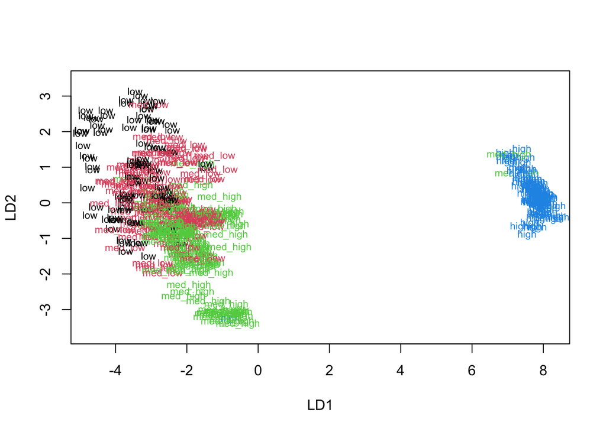

```r
# target classes as numeric
classes <- as.numeric(train$crime)

# plot the lda results
plot(lda_fit, dimen = 2, col = classes, pch = classes)
```

## Predictions and Cross-tabulation

```r
# Save the crime categories from the test set
correct_classes <- test$crime

# Remove the categorical crime variable from the test dataset
test <- dplyr::select(test, -crime)

# Predict the classes with the LDA model on the test data
lda_pred <- predict(lda_fit, newdata = test)$class

# Cross-tabulate the results with the crime categories from the test set
table(correct_classes, lda_pred)
```

```
##                lda_pred
## correct_classes low med_low med_high high
##        low       15       8        2    0
##        med_low    1      19        2    0
##        med_high   0       8       19    4
##        high       0       0        0   24
```

In essence, this table offers a granular view of the model’s strengths and areas for improvement across different crime categories. It provides valuable insights for refining the model and enhancing its accuracy in predicting crime rates.

## Clustering

```r
# Reload the Boston dataset
data(Boston)

# Standardize the dataset
boston_scaled <- scale(Boston)

# Calculate distances between observations
dist_eu <- dist(boston_scaled)
summary(dist_eu)
```

```
##    Min. 1st Qu.  Median    Mean 3rd Qu.    Max.
##  0.1343  3.4625  4.8241  4.9111  6.1863 14.3970
```

## k-means algorithm with varying numbers of clusters (k)

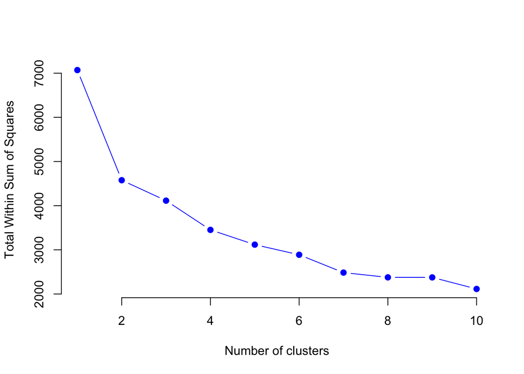

```r
# Determine the number of clusters
k_max <- 10

# Calculate total within-cluster sum of squares (TWSS) for different cluster numbers
twss <- sapply(1:k_max, function(k) kmeans(boston_scaled, centers = k)$tot.withinss)

# Visualize the TWSS
plot(1:k_max, twss, type = "b", pch = 19, frame = FALSE, col = "blue", xlab = "Number of clusters", ylab = "Total Within Sum of Squares")
```

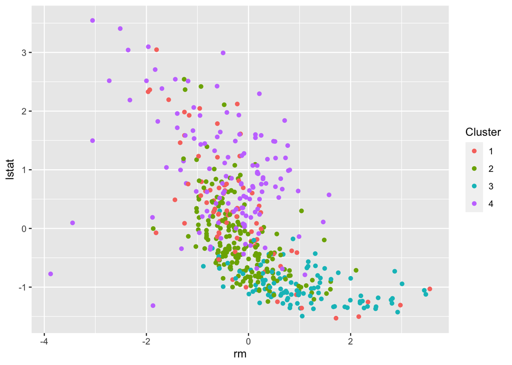

```r
# Choose the optimal number of clusters
optimal_clusters <- 4

# Run k-means with the optimal number of clusters
kmeans_result <- kmeans(boston_scaled, centers = optimal_clusters)

# Creating a data frame for plotting
plot_data <- as.data.frame(boston_scaled)
plot_data$cluster <- factor(kmeans_result$cluster)

# Visualize clusters using pairs() with colors
ggplot(plot_data, aes(x = rm, y = lstat)) +
  geom_point(aes(color = cluster)) +
  labs(color = 'Cluster')
```

**Cluster Distribution:** The plot shows how the observations are grouped into four different clusters. Each cluster is represented by a different color.

**Correlation Inference:** The negative correlation between the number of rooms (`rm`) and the percentage of lower-status population (`lstat`) aligns with our expectations. In areas with more rooms, there tends to be a lower percentage of lower-status residents.

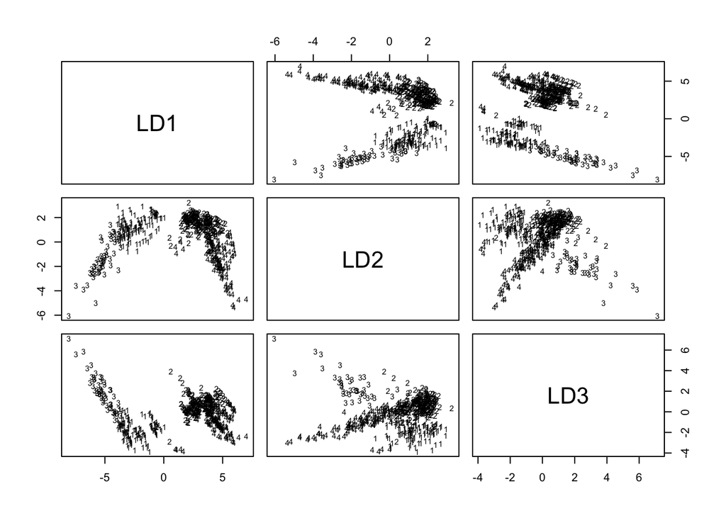

```r
# Standardize the original Boston dataset
original_boston_scaled <- as.data.frame(scale(Boston))

# Perform k-means with some reasonable number of clusters
reasonable_clusters <- 4
kmeans_original <- kmeans(original_boston_scaled, centers = reasonable_clusters)

# Perform LDA using the clusters as target classes
lda_fit <- lda(kmeans_original$cluster ~ ., data = original_boston_scaled)

# Visualize LDA results with a biplot
plot(lda_fit)
```

```r
lda_fit$scaling
```

```
##                 LD1         LD2          LD3
## crim    -0.31028992 -0.62224451  0.597212526
## zn      -0.09338930 -0.96434025 -0.716986122
## indus   -1.40992137  0.16185691 -1.004128879
## chas     0.06950551  0.12316233  0.073570823
## nox     -0.48313830 -0.10654440 -0.870736311
## rm       0.25553149 -0.52639418 -0.282378921
## age     -0.07134757  0.31940794 -0.045053040
## dis      0.06345902 -0.01924507 -0.380206568
## rad     -0.85654373 -0.09761292  0.003307117
## tax     -0.37874646 -0.14644700 -0.545068105
## ptratio -0.01835256  0.12874013  0.128579267
## black    0.56785879  0.68819820 -0.950512993
## lstat   -0.09283319 -0.55997738  0.261272880
## medv     0.20180072 -0.60601649 -0.347080865
```

These coefficients indicate the direction and strength of the relationship between the original variables and the discriminants.